# R Notebook

# Intro

Starting to dive into the data!

# Setup

## Load Packages

```r
library(ggplot2)
library(dplyr)
library(tm)
library(stringr)
library(jsonlite)
library(googlesheets)
library(randomForest)
```

## Load data

```r
raw_data <- read.csv("./data/CLEAN-DATA.csv", stringsAsFactors = F)
CleanDataKeyEntry <- gs_title("CleanDataKeyEntry")
```

```r
main_data <- gs_read(CleanDataKeyEntry, ws = "MainData")
```

# NTEE Cleaning

In a quick peek of the data, we see the NTEE code column has 26.61 percent missing. Multiple codes are allowed, so we will set out on imputing some missing values.

## Parsing JSON NTEE codes to data frame

In order to join the NTEE code list to the data, we need to parse the JSON file to a data frame. And bonus: add it to the Google sheet! Note that not all codes have keywords assocaited with them. Keywords are separated with “|”.

```r
ntee <- fromJSON("./data/ntee.json", simplifyDataFrame = T, flatten = T)
ntee_df <- data.frame(code = c(),
                    title = c(),
                    desc = c(),
                    keywords = c()
                    )
for (i in 1:length(ntee)) {
  code_add      <- names(ntee)[i]
  code_data     <- ntee[[i]]
  code_desc     <- code_data$description
  code_keywords <- paste(code_data$keywords, collapse = "|")
  code_title    <- code_data$title

  data_add <- data.frame(code     = code_add,
                         title    = code_title,
                         desc     = code_desc,
                         keywords = code_keywords
                         )
  ntee_df <- rbind(ntee_df, data_add)
}
# CleanDataKeyEntry <- CleanDataKeyEntry %>%
#   gs_ws_new(ws_title = "NTEE Codes", input = ntee_df)
```

## Create table of NPO name and and codes

The aid with the cleaning, we’ll reduce the raw data to a table of NPO names and associated codes.

*work paused on this*

# NTEE Top Level Feature Creation

# Give Reason Analysis

Let’s see if we can do a basic model of giving reason. Giving reasons: 1 = Personal, 2 = Invested, 3 = Exposure, 4 = ??, NA

## Data Cleaing and Subsetting

Since not all NPOs matched well to the Guidestar data, we’ll follow the convention of filtering out observations that were not good matches using *Inclusion == TRUE*

```r
gr_data <- main_data %>%
  filter(Inclusion == TRUE)
# Recode give reason
## Recoding gr_data$give_reason into gr_data$give_reason2
## Recoding gr_data$give_reason_vlook into gr_data$give_reason2
gr_data$give_reason2 <- gr_data$give_reason_vlook
gr_data$give_reason2[gr_data$give_reason_vlook == "1"] <- "Personal"
gr_data$give_reason2[gr_data$give_reason_vlook == "2"] <- "Invested"
gr_data$give_reason2[gr_data$give_reason_vlook == "3"] <- "Exposure"
gr_data$give_reason2[gr_data$give_reason_vlook == "#N/A"] <- "Not Found"
gr_data$give_reason2[gr_data$give_reason_vlook == "??"] <- "Not Found"
gr_data$give_reason2[gr_data$give_reason_vlook == "4"] <- "Other"
gr_data$give_reason2[is.na(gr_data$give_reason_vlook)] <- "Not Found"
gr_data$give_reason2 <- factor(gr_data$give_reason2)
```

## Frequency plot

A quick check of frequency of give reason. Filtered for the 3 main give reasons.

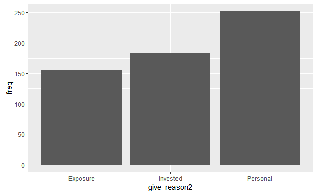

```r
gr_data %>%
  filter(give_reason_vlook %in% c("1", "2", "3")) %>%
  group_by(give_reason2) %>%
  summarise(freq = n()) %>%
  ggplot(aes(give_reason2, freq)) +
    geom_bar(stat = "Identity")
```

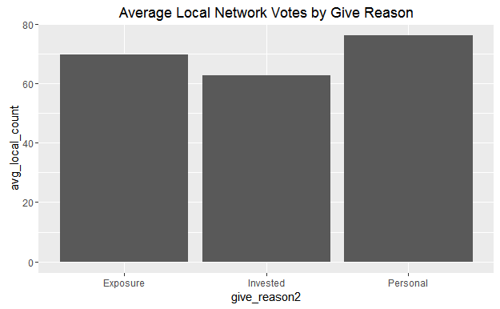

```r
gr_data %>%
  filter(give_reason_vlook %in% c("1", "2", "3")) %>%
  group_by(give_reason2) %>%
  summarise(avg_local_count = mean(votes_local_network, na.rm = T)) %>%
  ggplot(aes(give_reason2, avg_local_count)) +
  geom_bar(stat = "Identity") +
  ggtitle("Average Local Network Votes by Give Reason")
```

## Give Reason Freq by Photo

Plot of give reason frequncy by if Photo was included or not.

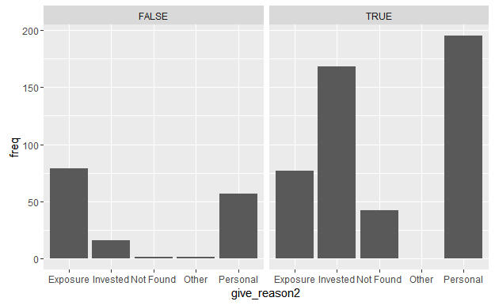

```r
gr_data %>%
  group_by(give_reason2, Photo) %>%
    summarise(freq = n()) %>%
  ggplot(aes(give_reason2, freq)) +
    geom_bar(stat = "Identity") +
  facet_wrap(~ Photo)
```

## Give Reason Freq by top level email domain

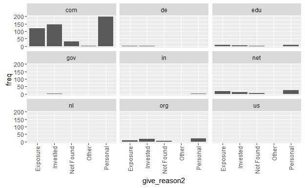

```r
gr_data %>%
  group_by(give_reason2, EmailTLD) %>%
    summarise(freq = n()) %>%
  ggplot(aes(give_reason2, freq)) +
    geom_bar(stat = "Identity") +
  facet_wrap(~ EmailTLD) +
  theme(axis.text.x=element_text(angle=90,hjust=1,vjust=0.5))
```

A bit sparse for somedomains, so let’s recode as *com = 1/0* where 1 = “was .com” and 0 = “not .com”.

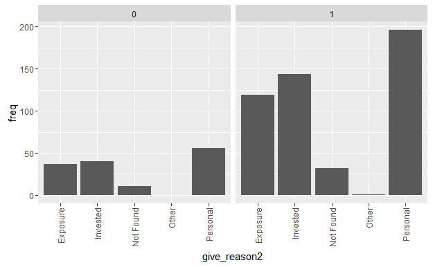

```r
## Recoding gr_data$EmailTLD into gr_data$com
gr_data$com <- gr_data$EmailTLD
gr_data$com[gr_data$EmailTLD == "com"] <- "1"
gr_data$com[gr_data$EmailTLD == "net"] <- "0"
gr_data$com[gr_data$EmailTLD == "in"] <- "0"
gr_data$com[gr_data$EmailTLD == "edu"] <- "0"
gr_data$com[gr_data$EmailTLD == "org"] <- "0"
gr_data$com[gr_data$EmailTLD == "gov"] <- "0"
gr_data$com[gr_data$EmailTLD == "de"] <- "0"
gr_data$com[gr_data$EmailTLD == "us"] <- "0"
gr_data$com[gr_data$EmailTLD == "nl"] <- "0"
gr_data$com <- as.numeric(gr_data$com)
gr_data %>%
  group_by(give_reason2, com) %>%
    summarise(freq = n()) %>%
  ggplot(aes(give_reason2, freq)) +
    geom_bar(stat = "Identity") +
  facet_wrap(~ com) +
  theme(axis.text.x = element_text(angle=90,hjust=1,vjust=0.5))
```

## Give Reason freq by high level NTEE

```r
# gr_data <- gr_data %>%
#   mutate()
```

## Multinomal Model of Give Reason

A basic multinomial model if give reason were we consider give reason == NA as a valid choice (i.e. choice not to disclose either purposefully or not)

```r
library(nnet)
gr_model_1 <- gr_data %>%
 multinom(give_reason2 ~ Photo + give_method + com, data = .)
summary(gr_model_1)
```

```
Call:
multinom(formula = give_reason2 ~ Photo + give_method + com,
    data = .)

Coefficients:
          (Intercept)  PhotoTRUE give_method       com
Invested   -2.7448649  1.9411047  0.25465922 0.6806421
Not Found  -5.6350422  3.5715913  0.19955537 1.1029613
Other      -9.6711982 -9.1273520  0.11148336 5.4327412
Personal   -0.6511398  0.7465213  0.03912442 0.2093547

Std. Errors:
          (Intercept)   PhotoTRUE give_method        com
Invested    0.5491491   0.3984631   0.1376458  0.4447368
Not Found   1.3004336   1.0726041   0.1934027  0.8199954
Other      25.1360762 161.0988733   1.0069457 25.0736816
Personal    0.4006460   0.3220137   0.1295360  0.3351411

Residual Deviance: 591.5439
AIC: 623.5439
```

# Vote Count Prediction

Let’s see if we can build a predictive model for vote count. What factors are predictive of story vote count. Since we expect there to be a bit of a network effect with people that have a large number of friends getting large local vote counts, we will use gallery_count/local_count as the response variable. To start, we’ll simply focus on getting a feature impotance list.

## Feature Extraction and Model Building

Let’s extract some key features.

```r
# Extract columns to keep
set.seed(101)
keep_cols <- c("votes_gallery_(Calc)"
               ,"votes_local_network"
               ,"InferredGender"
               ,"TextLength"
               ,"NumWords"
               ,"NumPunctuation"
               ,"NumURLs"
               ,"NumHashtags"
               ,"NumAtMentions"
               ,"NumDollarsigns"
               ,"NumDigits"
               ,"NumExclamationpoints"
               ,"NumUppercaseletters"
               ,"EmailTLD"
               ,"ScrabbleScore"
               ,"Total Revenue"
               ,"Photo"
               ,"give_reason2"
               #,"give_method_vlookup"
               ,"give_method"
               ,"SentimentScore"
               ,"EmailDomain"
               )
vm_data <- gr_data %>%
  select(one_of(keep_cols))
# Target
vm_data$target <- round(vm_data$`votes_gallery_(Calc)`/vm_data$votes_local_network,2)
# Some Cleaning
vm_data$total_revenue <- as.numeric(gsub("\\,", '', sub('\\$','',as.character(vm_data$`Total Revenue`))))
vm_data$sentiment_clean <- round(as.numeric(vm_data$SentimentScore),5)
vm_data$InferredGender <- as.factor(vm_data$InferredGender)
vm_data$EmailTLD <- as.factor(vm_data$EmailTLD)
vm_data$Photo <- as.factor(vm_data$Photo)
vm_data$EmailDomain <- as.factor(vm_data$EmailDomain)
#vm_data$give_method_vlookup <- as.factor(vm_data$give_method_vlookup)
vm_data$give_method <- as.factor(vm_data$give_method)
# Drop old features
drop_cols <- c("SentimentScore"
               ,"Total Revenue"
               ,"votes_gallery_(Calc)"
               ,"votes_local_network")
vm_data <- vm_data %>% select(-one_of(drop_cols))
# Remove NA's in respose
vm_data <- vm_data %>% filter(!is.na(target))
vm_data2 <- na.roughfix(vm_data)
# Basic GBM for importance
vm_gbm <- gbm(log(target+1) ~.
              ,data = vm_data2
              ,distribution = "gaussian"
              ,n.trees = 1000
              ,interaction.depth = 5
              ,n.minobsinnode = 15
              ,shrinkage = 0.005
              ,bag.fraction = 0.5
              ,train.fraction = 0.7
              ,verbose = TRUE)
```

```
     1        0.0581          0.0428     0.0050    0.0000
     2        0.0580          0.0428     0.0050    0.0000
     3        0.0580          0.0429     0.0050   -0.0001
     4        0.0579          0.0430     0.0050   -0.0000
     5        0.0578          0.0430     0.0050    0.0000
     6        0.0577          0.0431     0.0050   -0.0000
     7        0.0577          0.0432     0.0050   -0.0000
     8        0.0576          0.0432     0.0050   -0.0000
     9        0.0575          0.0432     0.0050    0.0000
    10        0.0575          0.0433     0.0050   -0.0000
    20        0.0568          0.0438     0.0050   -0.0000
    40        0.0555          0.0453     0.0050    0.0000
    60        0.0543          0.0470     0.0050   -0.0000
    80        0.0532          0.0486     0.0050   -0.0000
   100        0.0524          0.0504     0.0050   -0.0000
```

[output cut: 45 more lines]

```
                                      var      rel.inf
EmailDomain                   EmailDomain 51.676327314
NumWords                         NumWords  6.498360515
NumPunctuation             NumPunctuation  6.115294418
NumDigits                       NumDigits  5.346772478
NumUppercaseletters   NumUppercaseletters  5.063257980
sentiment_clean           sentiment_clean  5.011909772
ScrabbleScore               ScrabbleScore  4.840293255
TextLength                     TextLength  3.416845265
total_revenue               total_revenue  3.047372543
give_method                   give_method  2.606256539
give_reason2                 give_reason2  2.212373566
NumURLs                           NumURLs  1.292623249
Photo                               Photo  1.029293856
NumExclamationpoints NumExclamationpoints  0.697542968
NumHashtags                   NumHashtags  0.648278951
NumDollarsigns             NumDollarsigns  0.256259329
InferredGender             InferredGender  0.232770032
EmailTLD                         EmailTLD  0.008167969
NumAtMentions               NumAtMentions  0.000000000
```

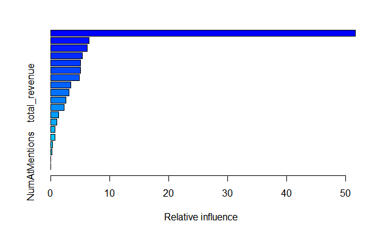

```r
summary(vm_gbm)
```

```
Using test method...
[1] 1
```

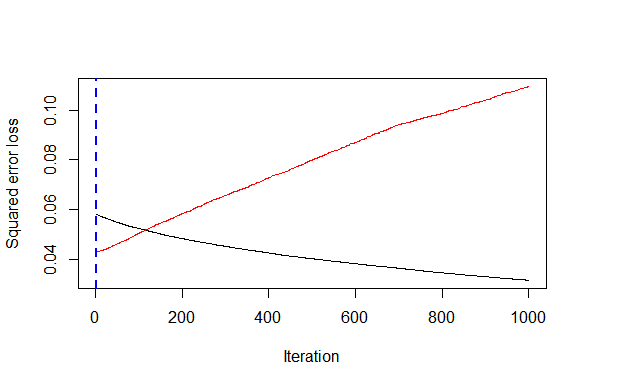

```r
gbm.perf(vm_gbm)
```

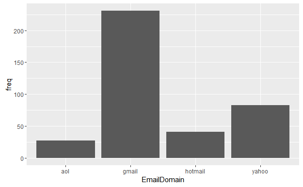

```r
vm_data2 %>% group_by(EmailDomain) %>%
  summarise(freq = n()) %>%
  filter(freq >= 25) %>%
  ggplot(aes(EmailDomain, freq)) +
  geom_bar(stat="identity")
```

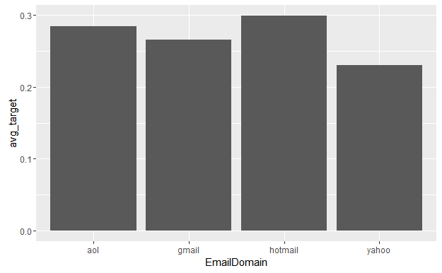

```r
vm_data2 %>% group_by(EmailDomain) %>%
  summarise(avg_target = mean(target)
            ,freq = n()) %>%
  filter(freq >= 25) %>%
  ggplot(aes(EmailDomain, avg_target)) +
  geom_bar(stat="identity")
```

## Modelinh gallery count directly

Let’s extract some key features.

```r
set.seed(101)
# Extract columns to keep
keep_cols <- c("votes_gallery_(Calc)"
               ,"InferredGender"
               ,"TextLength"
               ,"NumWords"
               ,"NumPunctuation"
               ,"NumURLs"
               ,"NumHashtags"
               ,"NumAtMentions"
               ,"NumDollarsigns"
               ,"NumDigits"
               ,"NumExclamationpoints"
               ,"NumUppercaseletters"
               ,"EmailTLD"
               ,"ScrabbleScore"
               ,"Total Revenue"
               ,"Photo"
               ,"give_reason2"
               #,"give_method_vlookup"
               ,"give_method"
               ,"SentimentScore"
               ,"EmailDomain"
               )
vm_data <- gr_data %>%
  select(one_of(keep_cols))
# Target
vm_data$target <- vm_data$'votes_gallery_(Calc)'
# Some Cleaning
# Use total revenue on log scale due to some biiiig values
vm_data$total_revenue <- log(as.numeric(gsub("\\,", '', sub('\\$','',as.character(vm_data$`Total Revenue`)))))
vm_data$sentiment_clean <- round(as.numeric(vm_data$SentimentScore),5)
vm_data$InferredGender <- as.factor(vm_data$InferredGender)
vm_data$EmailTLD <- as.factor(vm_data$EmailTLD)
vm_data$Photo <- as.factor(vm_data$Photo)
vm_data$EmailDomain <- as.factor(vm_data$EmailDomain)
#vm_data$give_method_vlookup <- as.factor(vm_data$give_method_vlookup)
vm_data$give_method <- as.factor(vm_data$give_method)
# Drop old features
drop_cols <- c("SentimentScore"
               ,"Total Revenue"
               ,"votes_gallery_(Calc)"
               ,"votes_local_network")
vm_data <- vm_data %>% select(-one_of(drop_cols))
# Remove NA's in respose
vm_data <- vm_data %>% filter(!is.na(target))
vm_data2 <- na.roughfix(vm_data)
# Basic GBM for importance
vm_gbm2 <- gbm(target ~.
              ,data = vm_data2
              ,distribution = "poisson"
              ,n.trees = 1000
              ,interaction.depth = 5
              ,n.minobsinnode = 15
              ,shrinkage = 0.001
              ,bag.fraction = 0.6
              ,train.fraction = 0.5
              ,verbose = TRUE)
```

```
     1     -109.9830        -80.2110     0.0010    0.0098
     2     -110.0505        -80.2388     0.0010    0.0085
     3     -110.1121        -80.2737     0.0010    0.0115
     4     -110.1733        -80.3089     0.0010    0.0089
     5     -110.2266        -80.3305     0.0010    0.0143
     6     -110.2853        -80.3588     0.0010    0.0005
     7     -110.3637        -80.3862     0.0010    0.0167
     8     -110.4257        -80.4080     0.0010    0.0077
     9     -110.4969        -80.4416     0.0010    0.0113
    10     -110.5806        -80.4801     0.0010    0.0102
    20     -111.2035        -80.7839     0.0010    0.0221
    40     -112.4189        -81.2696     0.0010    0.0267
    60     -113.6374        -81.7274     0.0010    0.0213
    80     -114.8433        -82.2123     0.0010    0.0249
   100     -115.9866        -82.6304     0.0010    0.0100
```

[output cut: 45 more lines]

```
                                      var     rel.inf
EmailDomain                   EmailDomain 77.90690851
NumDigits                       NumDigits  9.10736707
sentiment_clean           sentiment_clean  2.53610796
ScrabbleScore               ScrabbleScore  2.31201466
NumUppercaseletters   NumUppercaseletters  2.25971260
NumPunctuation             NumPunctuation  1.51588320
total_revenue               total_revenue  1.11159420
NumWords                         NumWords  1.05740662
TextLength                     TextLength  0.69875896
give_reason2                 give_reason2  0.55477469
NumURLs                           NumURLs  0.28483714
NumExclamationpoints NumExclamationpoints  0.20914699
EmailTLD                         EmailTLD  0.18181533
NumDollarsigns             NumDollarsigns  0.13355132
Photo                               Photo  0.07556980
NumHashtags                   NumHashtags  0.02620038
InferredGender             InferredGender  0.01618871
give_method                   give_method  0.01216187
NumAtMentions               NumAtMentions  0.00000000
```

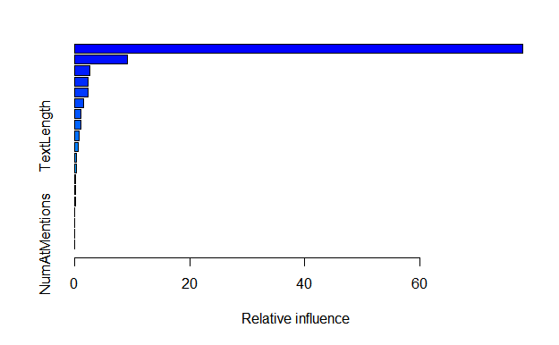

```r
summary(vm_gbm2)
```

```
Using test method...
[1] 413
```

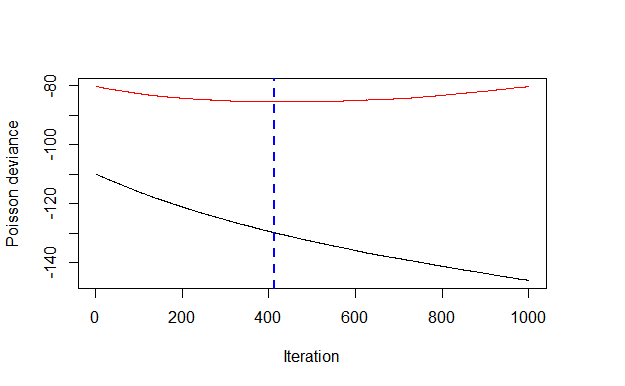

```r
gbm.perf(vm_gbm2)
```

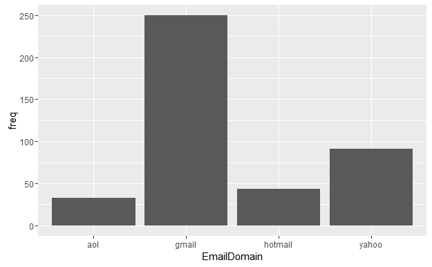

```r
vm_data2 %>% group_by(EmailDomain) %>%
  summarise(freq = n()) %>%
  filter(freq >= 25) %>%
  ggplot(aes(EmailDomain, freq)) +
  geom_bar(stat="identity")
```

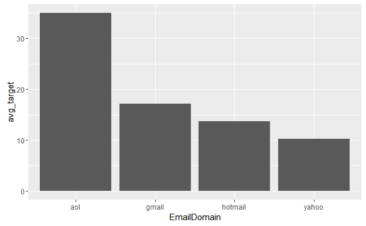

```r
vm_data2 %>% group_by(EmailDomain) %>%
  summarise(avg_target = mean(target)
            ,freq = n()) %>%
  filter(freq >= 25) %>%
  ggplot(aes(EmailDomain, avg_target)) +
  geom_bar(stat="identity")
```

Interestingly the GBM picks up on email domain which exhibits an interesting pattern with gallery vote count.

## Modeling network votes directly

```r
set.seed(101)
# Extract columns to keep
keep_cols <- c("votes_local_network"
               ,"InferredGender"
               ,"TextLength"
               ,"NumWords"
               ,"NumPunctuation"
               ,"NumURLs"
               ,"NumHashtags"
               ,"NumAtMentions"
               ,"NumDollarsigns"
               ,"NumDigits"
               ,"NumExclamationpoints"
               ,"NumUppercaseletters"
               ,"EmailTLD"
               ,"ScrabbleScore"
               ,"Total Revenue"
               ,"Photo"
               ,"give_reason2"
               #,"give_method_vlookup"
               ,"give_method"
               ,"SentimentScore"
               ,"EmailDomain"
               )
vm_data <- gr_data %>%
  select(one_of(keep_cols))
# Target
vm_data$target <- vm_data$votes_local_network
# Some Cleaning
# Use total revenue on log scale due to some biiiig values
vm_data$total_revenue <- log(as.numeric(gsub("\\,", '', sub('\\$','',as.character(vm_data$`Total Revenue`)))))
vm_data$sentiment_clean <- round(as.numeric(vm_data$SentimentScore),5)
vm_data$InferredGender <- as.factor(vm_data$InferredGender)
vm_data$EmailTLD <- as.factor(vm_data$EmailTLD)
vm_data$Photo <- as.factor(vm_data$Photo)
vm_data$EmailDomain <- as.factor(vm_data$EmailDomain)
#vm_data$give_method_vlookup <- as.factor(vm_data$give_method_vlookup)
vm_data$give_method <- as.factor(vm_data$give_method)
# Drop old features
drop_cols <- c("SentimentScore"
               ,"Total Revenue"
               ,"votes_local_network")
vm_data <- vm_data %>% select(-one_of(drop_cols))
# Remove NA's in respose
vm_data <- vm_data %>% filter(!is.na(target))
vm_data2 <- na.roughfix(vm_data)
# Basic GBM for importance
vm_gbm2 <- gbm(target ~.
              ,data = vm_data2
              ,distribution = "poisson"
              ,n.trees = 1000
              ,interaction.depth = 5
              ,n.minobsinnode = 15
              ,shrinkage = 0.001
              ,bag.fraction = 0.6
              ,train.fraction = 0.5
              ,verbose = TRUE)
```

```
     1     -664.4280       -718.2216     0.0010    0.0227
     2     -664.6847       -718.3908     0.0010    0.0170
     3     -664.8233       -718.3249     0.0010    0.0025
     4     -665.0343       -718.5241     0.0010    0.0701
     5     -665.2114       -718.6742     0.0010    0.0600
     6     -665.3894       -718.7719     0.0010    0.0369
     7     -665.6332       -718.9698     0.0010    0.0936
     8     -665.9070       -719.2124     0.0010    0.0500
     9     -666.1563       -719.4659     0.0010   -0.0048
    10     -666.4099       -719.6238     0.0010    0.0511
    20     -668.6838       -720.9855     0.0010    0.0059
    40     -673.3888       -724.3843     0.0010    0.0594
    60     -677.7790       -726.8826     0.0010    0.0315
    80     -682.4291       -729.9899     0.0010   -0.0006
   100     -686.7365       -732.4044     0.0010   -0.0016
```

[output cut: 45 more lines]

```
                                      var      rel.inf
EmailDomain                   EmailDomain 7.384305e+01
NumDigits                       NumDigits 1.024856e+01
NumPunctuation             NumPunctuation 3.711256e+00
total_revenue               total_revenue 2.329482e+00
NumUppercaseletters   NumUppercaseletters 2.268849e+00
ScrabbleScore               ScrabbleScore 1.894315e+00
sentiment_clean           sentiment_clean 1.660793e+00
EmailTLD                         EmailTLD 1.153837e+00
NumExclamationpoints NumExclamationpoints 9.245763e-01
TextLength                     TextLength 6.539437e-01
NumWords                         NumWords 5.982988e-01
give_reason2                 give_reason2 4.028648e-01
NumURLs                           NumURLs 1.909499e-01
Photo                               Photo 4.379032e-02
InferredGender             InferredGender 3.907934e-02
NumDollarsigns             NumDollarsigns 3.425031e-02
NumHashtags                   NumHashtags 1.101901e-03
give_method                   give_method 9.992094e-04
NumAtMentions               NumAtMentions 0.000000e+00
```

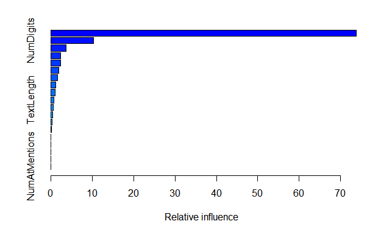

```r
summary(vm_gbm2)
```

```
Using test method...
[1] 603
```

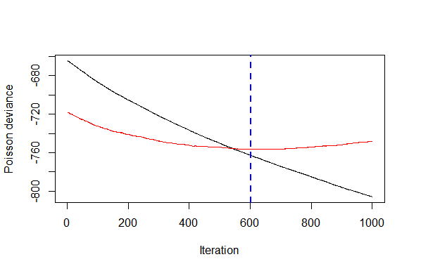

```r
gbm.perf(vm_gbm2)
```

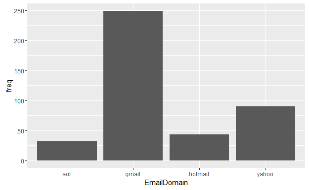

```r
vm_data2 %>% group_by(EmailDomain) %>%
  summarise(freq = n()) %>%
  filter(freq >= 25) %>%
  ggplot(aes(EmailDomain, freq)) +
  geom_bar(stat="identity")
```

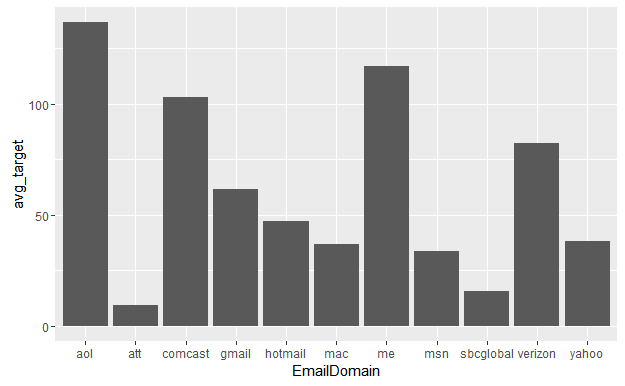

```r
vm_data2 %>% group_by(EmailDomain) %>%
  summarise(avg_target = mean(target)
            ,freq = n()) %>%
  filter(freq >= 5) %>%
  ggplot(aes(EmailDomain, avg_target)) +
  geom_bar(stat="identity")
```

## Modeling Total votes directly

```r
set.seed(101)
# Extract columns to keep
keep_cols <- c("votes_total"
               ,"InferredGender"
               ,"TextLength"
               ,"NumWords"
               ,"NumPunctuation"
               ,"NumURLs"
               ,"NumHashtags"
               ,"NumAtMentions"
               ,"NumDollarsigns"
               ,"NumDigits"
               ,"NumExclamationpoints"
               ,"NumUppercaseletters"
               ,"EmailTLD"
               ,"ScrabbleScore"
               ,"Total Revenue"
               ,"Photo"
               ,"give_reason2"
               #,"give_method_vlookup"
               ,"give_method"
               ,"SentimentScore"
               ,"EmailDomain"
               )
vm_data <- gr_data %>%
  select(one_of(keep_cols))
# Target
vm_data$target <- vm_data$votes_total
# Some Cleaning
# Use total revenue on log scale due to some biiiig values
vm_data$total_revenue <- log(as.numeric(gsub("\\,", '', sub('\\$','',as.character(vm_data$`Total Revenue`)))))
vm_data$sentiment_clean <- round(as.numeric(vm_data$SentimentScore),5)
vm_data$InferredGender <- as.factor(vm_data$InferredGender)
vm_data$EmailTLD <- as.factor(vm_data$EmailTLD)
vm_data$Photo <- as.factor(vm_data$Photo)
vm_data$EmailDomain <- as.factor(vm_data$EmailDomain)
#vm_data$give_method_vlookup <- as.factor(vm_data$give_method_vlookup)
vm_data$give_method <- as.factor(vm_data$give_method)
# Drop old features
drop_cols <- c("SentimentScore"
               ,"Total Revenue"
               ,"votes_total")
vm_data <- vm_data %>% select(-one_of(drop_cols))
# Remove NA's in respose
vm_data <- vm_data %>% filter(!is.na(target))
vm_data2 <- na.roughfix(vm_data)
# Basic GBM for importance
vm_gbm2 <- gbm(target ~.
              ,data = vm_data2
              ,distribution = "poisson"
              ,n.trees = 1000
              ,interaction.depth = 5
              ,n.minobsinnode = 15
              ,shrinkage = 0.001
              ,bag.fraction = 0.6
              ,train.fraction = 0.5
              ,verbose = TRUE)
```

```
     1     -887.7450       -899.5548     0.0010    0.0740
     2     -888.0123       -899.4579     0.0010    0.0647
     3     -888.3545       -899.6424     0.0010    0.1072
     4     -888.6020       -899.5387     0.0010    0.0478
     5     -888.8127       -899.5404     0.0010    0.0281
     6     -889.1173       -899.7823     0.0010    0.0351
     7     -889.4578       -899.9169     0.0010    0.0799
     8     -889.7327       -900.1147     0.0010    0.0480
     9     -890.0807       -900.3054     0.0010    0.0660
    10     -890.4383       -900.5285     0.0010    0.0544
    20     -893.3455       -902.2250     0.0010    0.1065
    40     -898.7472       -905.0785     0.0010    0.1553
    60     -904.6250       -908.4169     0.0010    0.1024
    80     -910.2021       -911.4843     0.0010    0.0992
   100     -915.3009       -914.0927     0.0010    0.0657
```

[output cut: 45 more lines]

```
                                      var     rel.inf
EmailDomain                   EmailDomain 75.70826896
NumDigits                       NumDigits  9.47801973
NumPunctuation             NumPunctuation  3.33094681
NumUppercaseletters   NumUppercaseletters  2.65919282
ScrabbleScore               ScrabbleScore  1.98541308
total_revenue               total_revenue  1.69869400
sentiment_clean           sentiment_clean  1.65569848
EmailTLD                         EmailTLD  0.84608220
NumExclamationpoints NumExclamationpoints  0.74935169
TextLength                     TextLength  0.59026160
NumWords                         NumWords  0.54029826
give_reason2                 give_reason2  0.39580645
NumURLs                           NumURLs  0.21676021
NumDollarsigns             NumDollarsigns  0.07395441
Photo                               Photo  0.03186154
InferredGender             InferredGender  0.02796782
give_method                   give_method  0.01142194
NumHashtags                   NumHashtags  0.00000000
NumAtMentions               NumAtMentions  0.00000000
```

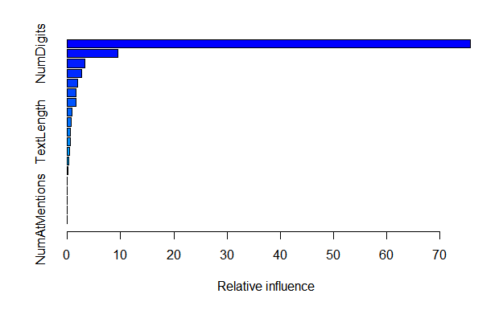

```r
summary(vm_gbm2)
```

```
Using test method...
[1] 666
```

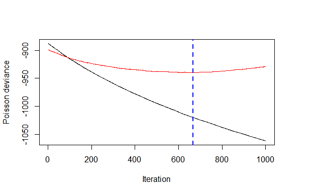

```r
gbm.perf(vm_gbm2)
```

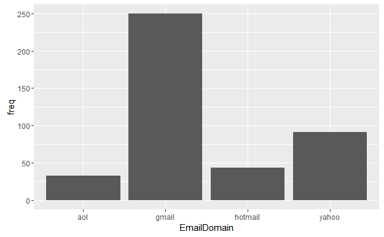

```r
vm_data2 %>% group_by(EmailDomain) %>%
  summarise(freq = n()) %>%
  filter(freq >= 25) %>%
  ggplot(aes(EmailDomain, freq)) +
  geom_bar(stat="identity")
```

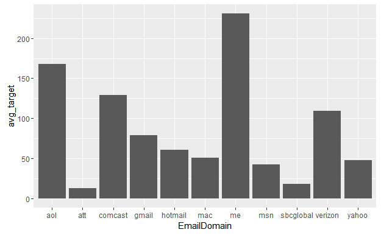

```r
vm_data2 %>% group_by(EmailDomain) %>%
  summarise(avg_target = mean(target)
            ,freq = n()) %>%
  filter(freq >= 5) %>%
  ggplot(aes(EmailDomain, avg_target)) +
  geom_bar(stat="identity")
```